# 3D Computer Vision (2024/25)

## Exercise

Upload: 30.10.2024 (11:30)

**Deadline**: 16.01.2025 (23:59)

### Your Group

Submitted by Group 01:

- Mohana Prasath Saravanan
- Chemezie Esiagu
- Henrik Schimmel

By submitting this exercise, you confirm the following:

- **All people** listed above **contributed** to this solution
- **No other people** were **involved** in this solution
- **No contents** of this solution were **copied from others** (this includes people, large language models, websites, etc.)

### Submission

Please hand in a single **.zip** file named according to the pattern "**groupXX**" (e.g. group00). The contents of the .zip should be as follows:

- folder with the same name as the **.zip** file
  - **.ipynb** file
  - **.html** export of .ipynb with all the outputs you got
  - **data** folder containing necessary files to run the code

I.e.

1. **unzip** the provided project.zip file
2. **rename** folder "project" according to the pattern "groupXX"
3. **solve** task inside .ipynb file
4. **export** notebook as .html (File > Download as > HTML)
5. **zip** folder groupXX
6. **submit** groupXX.zip

### Final Presentation

You will be required to present your solution in a 20 minute presentation, which includes:

- Problem Overview
- Solution Overview (e.g. pseudo code, mathematical formulas, visualizations)
- Describe challenges & optimizations

After the presentation, there will be 10 minutes of questions and answers about your work.

# 3D Scene Reconstruction

### Task Overview

Your task in this exercise is to do a dense reconstruction of a scene. This will involve multiple steps that you will encounter and learn about as the semester progresses. You can start implementing individual steps as soon as you learn about them or wait until you have learned more to implement everything together. In the latter case, be mindful that this exercise is designed for an entire semester and the workload is accordingly large.

You will be given the following data:

- **9 color images** of the scene.
  - 8 Bit RGB per pixel.
  - Each image rendered from a different position.
  - The camera used had **lens distortion**.
- **9 Depth images** of the scene.
  - 8 Bit Grayscale per pixel. The result of dividing the Z-depth by **each image's maximum** and then multiplying by 255.
  - Each image has the **same pose** as the corresponding RGB image.
  - The camera used was **free of any distortions**.
- 1 Dictionary containing **camera calibration parameters**.
  - They belong to the camera that was used to render the RGB images.
  - Distortion coefficients are given in the standard [k<sub>1</sub>, k<sub>2</sub>, p<sub>1</sub>, p<sub>2</sub>, k<sub>3</sub>] order.
- 1 Numpy array containing **8 camera transformations**.
  - They specify the **movements** that the **camera went through** to render all images.
  - I.e. idx **0** specifies the transformation from **00.png to 01.png**, idx **1** specifies the transformation from **01.png to 02.png**, ...
  - This applies to both RGB and Depth images, as they have the same poses.
- 1 Numpy array containing **7 features**.
  - The features are specified for each of the 9 images.
  - Each feature is a **2D pixel location in "H, W" order**, meaning the first value is the height/row in the image and the second width/column.
  - If a feature was not visible, it was entered as [-1, -1].
  - The features are **unsorted**, meaning that feature idx 0 for 00.png could be corresponding to e.g. feature idx 4 for 01.png.

### Solution requirements

- Your code needs to **compile**, **run**, and produce an **output**.
- Your target output should be a **dense point cloud** reconstruction (without holes) of the scene.
  - The output should be in the **.ply format**. We provide a function that can exports a .ply file.
  - You may inspect your .ply outputs in e.g. **Meshlab**.
  - See the 'Dense Point Cloud' sample image to get an idea of what is possible. (Meshlab screenshot with point shading set to None)
- Your code should be a **general solution**.
  - This means that it could run correctly for a different dataset (with same input structure).
  - It should **NOT** include anything **hardcoded** specific to this dataset.
- Your code should not be unnecessarily inefficient.
  - Our sample solution runs in less than 2 minutes total (including point cloud export).
  - If your solution runs for more than 10 minutes, you are being wasteful in some part of your program.

# Samples

### Image Distortion

[figure not shown]

### Cameras

[figure not shown]

### Cameras & Features

[figure not shown]

### Dense Point Cloud

[figure not shown]

# Imports

Please note the following:

- These are all imports necessary to achieve the sample results.
- You may remove and/or add other libraries at your own convinience.
- Using library functions (from the given or other libraries) that bypass **necessary computer vision tasks** will not be recognized as 'solved'.
  - E.g.: If you **need** to undistort an image to **get to the next step** of the solution and use the library function cv2.undistort(), then we will evaluate the **undistortion step** as '**failed**'.
  - E.g.: If you **want** to draw points in an image (to **check your method** or **visualize in-between steps**) and use the library function cv2.circle(), then there is **no problem**.
  - E.g.: If you **need** to perform complex **mathematical** operations and use some numpy function, then there is **no problem**.
  - E.g.: You do not like a **provided utility function** and find/know a library function that gives the **same outputs** from the **same inputs**, then there is **no problem**.

```python
!pip install opencv-contrib-python
!pip install ipympl
```

```python
import os
import torch
import cv2 as cv
import numpy as np
import matplotlib.pyplot as plt
from typing import List, Tuple, Union
import random
#make plots interactive:
%matplotlib widget
```

# Prepare Data

This should load all available data and also create some output directories. Feel free to rename variables or add additional directories as you see fit.

```python
#Inputs
base_path = os.getcwd()
data_path = os.path.join(base_path, f"data")
img_path = os.path.join(data_path, 'images')
depth_path = os.path.join(data_path, 'depths')
print(f"The project's root path is '{base_path}'.")
print(f"Reading data from '{data_path}'.")
print(f"Image folder: '{img_path}'.")
print(f"Depth folder: '{depth_path}'.")

#Outputs
out_path = os.path.join(base_path, 'output')
ply_path = os.path.join(out_path, 'point_cloud')
os.makedirs(out_path, exist_ok=True)
os.makedirs(ply_path, exist_ok=True)
print(f"\nCreating directory '{out_path}'.")
print(f"Creating directory '{ply_path}'.")

#Load Data
camera_calibration = np.load(os.path.join(data_path, 'camera_calibration.npy'), allow_pickle=True)
camera_calibration = camera_calibration.item()#get dictionary from numpy array struct
given_features = np.load(os.path.join(data_path, 'given_features.npy'), allow_pickle=True)
camera_movement = np.load(os.path.join(data_path, 'camera_movement.npy'), allow_pickle=True)

print(f"\nCamera Calibration:")
for entry in camera_calibration.items():
    print(f"  {entry[0]}: {entry[1]}")
print(f"Camera Movement: {camera_movement.shape}")#[Cameras-1, 4, 4]
print(f"2D Features (Unsorted): {given_features.shape}")#[Camera_idx, Feature_idx, 2]
```

```
The project's root path is 'C:\Users\thecr\3rd\3D CV\2. Dense 3D Construction'.
Reading data from 'C:\Users\thecr\3rd\3D CV\2. Dense 3D Construction\data'.
Image folder: 'C:\Users\thecr\3rd\3D CV\2. Dense 3D Construction\data\images'.
Depth folder: 'C:\Users\thecr\3rd\3D CV\2. Dense 3D Construction\data\depths'.

Creating directory 'C:\Users\thecr\3rd\3D CV\2. Dense 3D Construction\output'.
Creating directory 'C:\Users\thecr\3rd\3D CV\2. Dense 3D Construction\output\point_cloud'.

Camera Calibration:
  distortion_param: [-0.1, 0.02, 0.0, 0.0, -0.01]
  image_height: 551
  image_width: 881
  principal_point: [275.0, 440.0]
  focal_length_mm: 25
  sensor_width_mm: 35
  pixel_ratio: 1.0
  pixel_per_mm: 25.17142857142857
  focal_length_px: 629.2857142857142
Camera Movement: (8, 4, 4)
2D Features (Unsorted): (9, 7, 2)
```

# Provided Utility Functions

These functions are provided to reduce the complexity of some steps you might encounter. They were involved in the creation of the given samples. However, you do not have to use them and can use other means of achieving the same results.

```python
def sample_image(numpy_image, numpy_sample_grid):
    '''
    This function samples a target image from a source image (numpy_image) based on specified pixel coordinates (numpy_sample_grid).
    Inputs:
        numpy_image: of shape=[H, W, C]. H is the height, W is the width, and C is the color channel of the source image from which color values will be sampled.
        numpy_sample_grid: of shape=[H, W, UV]. H is the height and W is the width of the target image that will be sampled. UV are the pixel locations in the source image from which to sample color values.
    Outputs:
        sampled_image: of shape=[H, W, C]. H is the height, W is the width, and C is the color channel of the target image that was sampled.
    '''
    height, width, _ = numpy_image.shape#[H, W, 3]

    #turn numpy array to torch tensor
    torch_sample_grid = torch.from_numpy(numpy_sample_grid)#[H, W, 2]
    #normalize from range (0, width-1) to (0, 1)
    torch_sample_grid[:, :, 0] = torch_sample_grid[:, :, 0] / (width-1)
    #normalize from range (0, height-1) to (0, 1)
    torch_sample_grid[:, :, 1] = torch_sample_grid[:, :, 1] / (height-1)
    #normalize from range (0, 1) to (-1, 1)
    torch_sample_grid = torch_sample_grid*2 -1

    #transform to necessary shapes
    torch_sample_grid = torch_sample_grid.unsqueeze(0)#[1, H, W, 2]
    torch_image = torch.from_numpy(numpy_image).double().permute(2, 0, 1).unsqueeze(0)#[1, 3, H, W]
    #sample image according to sample grid locations from source image
    sampled_image = torch.nn.functional.grid_sample(torch_image, torch_sample_grid, mode='bilinear', padding_mode='zeros', align_corners=True)
    #transform back to numpy image
    sampled_image = sampled_image.squeeze().permute(1, 2, 0).numpy().astype(np.uint8)#[H, W, 3]
    return sampled_image

def ply_creator(input_3d, rgb_data=None, filename='dummy'):
    ''' Creates a colored point cloud that you can visualise using e.g. Meshlab.
    Inputs:
        input_3d: of shape=[N, 3], each row is the 3D coordinate of each point
        rgb_data(optional): of shape=[N, 3], each row is the rgb color value of each point
        filename: file name for the .ply file to be created
    '''
    assert (input_3d.ndim==2),"Pass 3d points as NumPointsX3 array "
    pre_text1 = """ply\nformat ascii 1.0"""
    pre_text2 = "element vertex "
    pre_text3 = """property float x\nproperty float y\nproperty float z\nproperty uchar red\nproperty uchar green\nproperty uchar blue\nend_header"""
    pre_text22 = pre_text2 + str(input_3d.shape[0])
    pre_text11 = pre_text1
    pre_text33 = pre_text3
    filename = filename + '.ply'
    fid = open(filename, 'w')
    fid.write(pre_text11)
    fid.write('\n')
    fid.write(pre_text22)
    fid.write('\n')
    fid.write(pre_text33)
    fid.write('\n')
    for i in range(input_3d.shape[0]):
        for c in range(3):
            fid.write(str(input_3d[i,c]) + ' ')
        if not rgb_data is None:
            for c in range(3):
                fid.write(str(rgb_data[i,c]) + ' ')
        if i!=input_3d.shape[0]:
            fid.write('\n')
    fid.close()
    return filename
```

```python
#The following is a simple toy example to see the behavior of the sample_image function
example_source = (np.random.rand(110, 220, 3)*255).astype(int)#[110, 220, 3]
example_grid = np.ones([100, 200, 2])#[100, 200, 2]
example_grid[:, :, 1] = 2
example_target = sample_image(example_source, example_grid)#[100, 200, 3]

#example_target will be of shape [100, 200, 3]
#100, because example_grid has a height of 100
#200, because example_grid has a width of 200
#3, because example_source has a color channel of 3
print(example_source.shape)

#example_target will contain the value of example_source[2, 1] at every pixel
#2, because example_grid[:, :, 1] has a value of 2 for every pixel
#1, because example_grid[:, :, 0] has a value of 1 for every pixel
print(example_source[2, 1, 0], "->", np.unique(example_target[:, :, 0]))
print(example_source[2, 1, 1], "->", np.unique(example_target[:, :, 1]))
print(example_source[2, 1, 2], "->", np.unique(example_target[:, :, 2]))
```

```
(110, 220, 3)
127 -> [127]
1 -> [1]
38 -> [38]
```

[output not shown]

[output cut: 8 more lines]

```
5.070295930756515 544.9297040692435
[[629.28571429   0.         440.        ]
 [  0.         629.28571429 275.        ]
 [  0.           0.           1.        ]] [[584.42286727   0.         440.        ]
 [  0.         584.42286727 275.        ]
 [  0.           0.           1.        ]]
19.92192029938741 860.0780797006125
5.070295930756515 544.9297040692435
[[629.28571429   0.         440.        ]
 [  0.         629.28571429 275.        ]
 [  0.           0.           1.        ]] [[584.42286727   0.         440.        ]
 [  0.         584.42286727 275.        ]
 [  0.           0.           1.        ]]
19.92192029938741 860.0780797006125
5.070295930756515 544.9297040692435
```

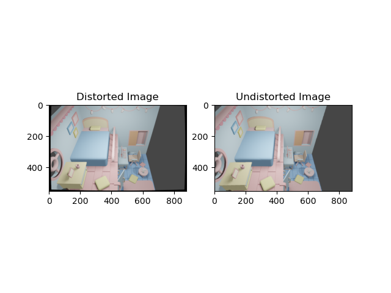

```python
import cv2 as cv
import numpy as np
os.environ['KMP_DUPLICATE_LIB_OK'] = 'True'

def undistort_image(image, camera_calibration):

    # parse camera params
    principal_point = camera_calibration["principal_point"]
    fx = fy = camera_calibration["focal_length_px"]
    sensor_width = camera_calibration["sensor_width_mm"]
    dist_coeffs = camera_calibration['distortion_param']
    k1, k2, p1, p2, k3 = dist_coeffs

    # convert intrinsics to pixel coordinates
    h, w = image.shape[:2]
    # fx = fx * (w / sensor_width)
    # fy = fy * (h / sensor_width)
    cy, cx = principal_point

    # opencv undistortion
    camera_matrix = np.array([[fx, 0, cx], [0, fy, cy], [0, 0, 1]])
    dist_coeffs = np.array(dist_coeffs)
    # dist_coeffs = np.array([0, 0, 0, 0, 0])
    new_camera_matrix, roi = cv.getOptimalNewCameraMatrix(camera_matrix, dist_coeffs, (w, h), 1, (w, h))
    undistorted_image_cv = cv.undistort(image, camera_matrix, dist_coeffs, None, new_camera_matrix)    # pixel coordiantes
    print(camera_matrix, new_camera_matrix)

    x = np.linspace(0, w - 1, w)
    y = np.linspace(0, h - 1, h)
    x_grid, y_grid = np.meshgrid(x, y)

    # normalized image coordinates
    x_norm = (x_grid - cx) / fx
    y_norm = (y_grid - cy) / fy

    # apply radial distortion
    r2 = x_norm**2  + y_norm**2
    r4 = r2**2
    r6 = r2**3

    x_distorted = x_norm * (1 + k1 * r2 + k2 * r4 + k3 * r6)
    y_distorted = y_norm * (1 + k1 * r2 + k2 * r4 + k3 * r6)

    # apply tangential distortion
    x_distorted = x_distorted + (2 * p1 * x_norm * y_norm + p2 * (r2 + 2 * x_norm**2))
    y_distorted = y_distorted + (p1 * (r2 + 2 * y_norm**2) + 2 * p2 * x_norm * y_norm)

    # pixel coordinates for the undistorted image
    x_pixel = x_distorted * fx + cx
    y_pixel = y_distorted * fy + cy

    print(x_pixel.min(), x_pixel.max())
    print(y_pixel.min(), y_pixel.max())

    # round-off the pixel coordinates
    x_pixel = np.round(x_pixel).astype(int)
    y_pixel = np.round(y_pixel).astype(int)

    # compute valid mask
    valid_mask_x = np.logical_and(x_pixel >= 0, x_pixel < w)
    valid_mask_y = np.logical_and(y_pixel >= 0, y_pixel < h)
    valid_mask = np.logical_and(valid_mask_x, valid_mask_y)

    # create the undistorted image
    undistorted_image = np.zeros((h, w, 3), dtype=np.uint8)

    y_ud = y_grid.reshape(h * w)[valid_mask.reshape(h * w)].astype(int)
    x_ud = x_grid.reshape(h * w)[valid_mask.reshape(h * w)].astype(int)

    y_d = y_pixel.reshape(h * w)[valid_mask.reshape(h * w)].astype(int)
    x_d = x_pixel.reshape(h * w)[valid_mask.reshape(h * w)].astype(int)

    undistorted_image[y_ud, x_ud, :] = image[y_d, x_d, :]


    # Crop the image to the region of interest if necessary
    # x, y, w, h = roi
    # undistorted_image = undistorted_image[y:y+h, x:x+w]

    return undistorted_image

# Example usage
# Load a sample image and camera parameters (assuming they're loaded in your notebook)
for idx in range(9):
    sample_image = cv.imread('data/images/{:02d}.png'.format(idx))
    undistorted_img = undistort_image(sample_image, camera_calibration)

    # save the undistorted image
    save_img_path = os.path.join("data/undistorted_images", "{:02d}.png".format(idx))
    cv.imwrite(save_img_path, undistorted_img)

# Display the result
plt.figure()
plt.subplot(1, 2, 1)
plt.title("Distorted Image")
plt.imshow(cv.cvtColor(sample_image, cv.COLOR_BGR2RGB))

plt.subplot(1, 2, 2)
plt.title("Undistorted Image")
plt.imshow(cv.cvtColor(undistorted_img, cv.COLOR_BGR2RGB))
plt.show()
```

```python
print(given_features.shape)
```

```
(9, 7, 2)
```

```python
given_features[0,:,:]
```

```
array([[163, 616],
       [431, 593],
       [380, 672],
       [164, 660],
       [378, 462],
       [280, 422],
       [274, 650]])
```

```python
given_features[1,:,:]
```

```
array([[192, 722],
       [183, 694],
       [398, 444],
       [495, 651],
       [495, 446],
       [346, 704],
       [282, 376]])
```

```python
# load the images
image_list = []
depth_list = []

distorted_image_list = []
for idx in range(9):
    image = cv.imread('data/undistorted_images/{:02d}.png'.format(idx))
    depth_image = cv.imread('data/depths/{:02d}.png'.format(idx), cv.IMREAD_GRAYSCALE)

    distorted_image = cv.imread('data/images/{:02d}.png'.format(idx))

    image_list.append(image)
    distorted_image_list.append(distorted_image)
    depth_list.append(depth_image)
```

```
[[170 170 170 ... 183 183 183]
 [170 170 170 ... 183 183 183]
 [170 170 170 ... 183 183 183]
 ...
 [166 166 166 ... 186 187 187]
 [166 166 166 ... 186 187 187]
 [166 166 166 ... 187 187 187]]
```

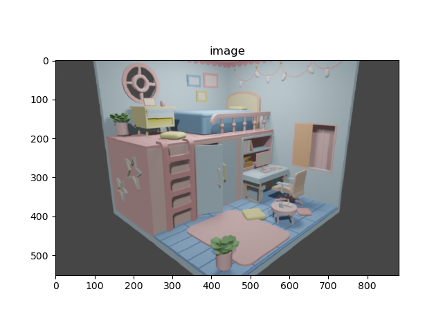

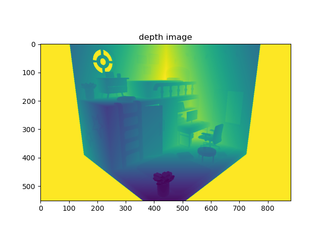

```python
# Display the result
plt.figure()
plt.title("image")
plt.imshow(cv.cvtColor(image_list[0], cv.COLOR_BGR2RGB))

print(depth_list[0][200:250, 400:450])
plt.figure()
plt.title("depth image")
plt.imshow(depth_list[0] / 255)
```

```python
# camera matrix
principal_point = camera_calibration["principal_point"]
fx = fy = camera_calibration["focal_length_px"]
cy, cx = principal_point

# opencv undistortion
camera_matrix = np.array([[fx, 0, cx], [0, fy, cy], [0, 0, 1]])
```

```python
camera_matrix
```

```
array([[629.28571429,   0.        , 440.        ],
       [  0.        , 629.28571429, 275.        ],
       [  0.        ,   0.        ,   1.        ]])
```

```python
def draw_points(image: np.ndarray,
               points: np.ndarray,
               color: Union[Tuple[int, int, int], List[Tuple[int, int, int]]] = (0, 255, 0),
               radius: int = 5,
               thickness: int = -1,  # -1 for filled circles
               with_numbers: bool = False,
               font_scale: float = 0.5,
               font_thickness: int = 1) -> np.ndarray:

    # Make a copy of the image to avoid modifying the original
    img_with_points = image.copy()

    # Convert points to integer coordinates
    points = np.round(points).astype(int)

    # Handle single color vs multiple colors
    if isinstance(color, tuple):
        colors = [color] * len(points)
    else:
        colors = color

    # Draw each point
    for i, (point, point_color) in enumerate(zip(points, colors)):
        x, y = point

        # Draw circle
        cv.circle(img_with_points, (x, y), radius, point_color, thickness)

        # Optionally draw point number
        if with_numbers:
            cv.putText(img_with_points, str(i), (x + radius, y + radius),
                       cv2.FONT_HERSHEY_SIMPLEX, font_scale, point_color,
                       font_thickness, cv2.LINE_AA)

    return img_with_points
```

```python
vis_img = draw_points(image_list[0], given_features[0][:, ::-1])
```

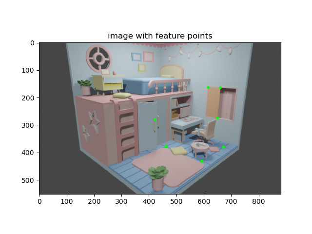

```python
# Display the result
plt.figure()
plt.title("image with feature points")
plt.imshow(cv.cvtColor(vis_img, cv.COLOR_BGR2RGB))
```

```python
given_features[0]
```

```
array([[163, 616],
       [431, 593],
       [380, 672],
       [164, 660],
       [378, 462],
       [280, 422],
       [274, 650]])
```

```python
given_features[0][:, ::-1]
```

```
array([[616, 163],
       [593, 431],
       [672, 380],
       [660, 164],
       [462, 378],
       [422, 280],
       [650, 274]])
```

```python
camera_movement[0]
```

```
array([[ 0.70710678, -0.1830127 ,  0.6830127 , -3.        ],
       [ 0.1830127 ,  0.98037987,  0.0732233 , -0.25881905],
       [-0.6830127 ,  0.0732233 ,  0.72672691,  0.96592583],
       [ 0.        ,  0.        ,  0.        ,  1.        ]])
```

```python
np.linalg.inv(camera_movement[0][:3, :3]) @ camera_movement[0][:3, [3]]
```

```
array([[-2.82842712],
       [ 0.3660254 ],
       [-1.3660254 ]])
```

```python
def compute_fundamental_matrix(K1, K2, P1, P2):

    R1, t1 = P1[:3, :3], P1[:3, [3]]
    R2, t2 = P2[:3, :3], P2[:3, [3]]

    # Compute relative rotation and translation
    R_rel = R2 @ R1.T
    t_rel = t2 - R_rel @ t1
    t_rel = t_rel.reshape((3,))

    # Create translation skew-symmetric matrix
    t_cross = np.array([
        [0, -t_rel[2], t_rel[1]],
        [t_rel[2], 0, -t_rel[0]],
        [-t_rel[1], t_rel[0], 0]
    ])

    # Compute essential matrix
    E = t_cross @ R_rel

    # Compute fundamental matrix
    F = np.linalg.inv(K2).T @ E @ np.linalg.inv(K1)

    return F
```

```python
def compute_distance_from_point_to_line(line, point):
    a, b, c = line
    x, y = point
    distance = abs(a * x + b * y + c) / ((a**2 + b**2)**0.5)

    return distance
```

```python
def draw_line(img, line, color=(0,255,0)):

    height, width = img.shape[:2]

    # Find intersection points with image borders
    x0, y0 = 0, int((-line[2])/line[1]) if line[1] != 0 else 0
    x1, y1 = width, int((-line[2] - line[0]*width)/line[1]) if line[1] != 0 else height

    # Draw line only if it intersects with image
    if 0 <= y0 <= height or 0 <= y1 <= height:
        cv.line(img, (x0, y0), (x1, y1), color, 1, cv.LINE_AA)

    return img
```

```python
def find_correspondences(points0, points1, epipolar_lines):
    n_points1 = points1.shape[1]
    n_lines = epipolar_lines.shape[1]

    distance_matrix = np.ones((n_points1, n_lines)) * 10000.0
    for p_idx in range(n_points1):
        pt = points1[:, p_idx]
        for l_idx in range(n_lines):
            pt0 = points0[:, l_idx]
            if pt0[0] < 0 or pt0[1] < 0 or  pt[0] < 0 or pt[1] < 0:
                distance_matrix[p_idx, l_idx] = 10000.0
            else:
                distance_matrix[p_idx, l_idx] = compute_distance_from_point_to_line(epipolar_lines[:, l_idx], pt)

    return distance_matrix
```

```python
def generate_colors(n):
    rgb_values = []
    for _ in range(n):
        rgb = (random.randint(0, 255), random.randint(0, 255), random.randint(0, 255))
        rgb_values.append(rgb)
    return rgb_values
```

```python
def sort_feature_points(ref_frame_idx, target_frame_idx, image_list,
                        camera_movement, camera_matrix, given_features, reverse=False):
    image0 = image_list[ref_frame_idx]
    image1 = image_list[target_frame_idx]

    pose_matrix = np.zeros((camera_movement.shape[0] + 1, 4, 4))
    pose_matrix[0, :, :] = np.eye(4)
    pose_matrix[1:, :, :] = camera_movement

    P = np.eye(4)
    for i in range(ref_frame_idx):
        P = pose_matrix[i + 1] @ P

    pose_ref = P

    for i in range(target_frame_idx - ref_frame_idx):
        P = pose_matrix[ref_frame_idx + i + 1] @ P

    pose_target = P

    # feature points
    points_ref = given_features[ref_frame_idx][:, ::-1].T.astype(float)
    points_target = given_features[target_frame_idx][:, ::-1].T.astype(float)

    # feature points homogeneous
    points_ref_h = np.vstack([points_ref, np.ones((points_ref.shape[1]))])
    points_target_h = np.vstack([points_target, np.ones((points_target.shape[1]))])

    if reverse:
        image1, image0 = image0, image1
        pose_ref, pose_target = pose_target, pose_ref
        points_ref, points_target = points_target, points_ref
        points_ref_h, points_target_h = points_target_h, points_ref_h

    # get fundamental matrix
    F = compute_fundamental_matrix(camera_matrix, camera_matrix, pose_ref, pose_target)

    # compute epipolar lines
    l = F @ points_ref_h

    # find correspondences
    distance_matrix = find_correspondences(points_ref, points_target, l)
    corr_idx = np.argmin(distance_matrix, axis=-1)

    return points_ref, points_target, corr_idx, pose_ref, pose_target
```

```python
def triangulate_matched_points(proj_mat0, proj_mat1, points0, points1):
    points4d = cv.triangulatePoints(proj_mat0, proj_mat1, points0, points1)
    points3d = points4d[:3, :] / points4d[3, :]
    points3d_h = points4d / points4d[3, :]

    return points3d_h
```

```python
def reproject_triangulated_points(proj_mat0, proj_mat1, points3d_h):
    # reproject the triangulated points
    reproj_points0 = proj_mat0 @ points3d_h
    reproj_points1 = proj_mat1 @ points3d_h

    reproj_points0 = reproj_points0[:2, :] / reproj_points0[2, :]
    reproj_points1 = reproj_points1[:2, :] / reproj_points1[2, :]

    return reproj_points0, reproj_points1
```

```python
def filter_mutual_matches(corr_idx, corr_idx_rev, points_ref, points_target):
    assert len(corr_idx) == len(corr_idx_rev)
    num_points = len(corr_idx)
    matches = list(zip(list(range(num_points)), corr_idx))
    matches_rev = list(zip(list(range(num_points)), corr_idx_rev))

    valid_matches = []
    valid_matches_rev = []

    for match in list(matches):
        if (match[1], match[0]) in matches_rev:
            pt_ref = points_ref[:, match[1]]
            pt_target = points_target[:, match[0]]

            if pt_ref[0] < 0 or pt_ref[1] < 0 or pt_target[0] < 0 or pt_target[1] < 0:
                pass
            else:
                valid_matches.append(match)
                valid_matches_rev.append((match[1], match[0]))

    num_valid_matches = len(valid_matches)

    points_ref_sorted = np.empty((2, num_valid_matches))
    points_target_sorted = np.empty((2, num_valid_matches))

    idx = 0
    for match in valid_matches:
        points_ref_sorted[:, idx] = points_ref[:, match[1]]
        points_target_sorted[:, idx] = points_target[:, match[0]]
        idx += 1

    return valid_matches, valid_matches_rev, points_ref_sorted, points_target_sorted
```

```python
def process_matches_and_triangulated_points(matches, depths, num_points):
    index_array = [-1] * num_points
    depth_array = [-1] * num_points

    idx = 0
    for match in matches:
        index_array[match[0]] = match[1]
        depth_array[match[0]] = depths[idx]
        idx += 1

    index_array = np.array(index_array).astype(int)
    depth_array = np.array(depth_array).astype(float)

    return index_array, depth_array
```

```python
# sort the feature points in target frame
matches_list = []
matches_rev_list = []
index_array_list= []
depth_array_list = []
pose_list = []

for i in range(len(image_list) - 1):
    ref_idx = 0
    target_idx = i + 1
    points_ref, points_target, corr_idx, pose_ref, pose_target = sort_feature_points(ref_idx, target_idx,
                                                                                     image_list, camera_movement,
                                                                                     camera_matrix, given_features,
                                                                                     reverse=False)

    points_ref_rev, points_target_rev, corr_idx_rev, pose_ref_rev, pose_target_rev = sort_feature_points(ref_idx, target_idx,
                                                                                     image_list, camera_movement,
                                                                                     camera_matrix, given_features,
                                                                                     reverse=True)

    if i == 0:
        pose_list.append(pose_ref)

    pose_list.append(pose_target)

    # filter mutual matches
    matches, matches_rev, points_ref_sorted, points_target_sorted = filter_mutual_matches(corr_idx, corr_idx_rev, points_ref, points_target)
    matches_list.append(matches)
    matches_rev_list.append(matches_rev)

    # triangualte matched points
    proj_mat_ref = camera_matrix @ pose_ref[:3, :]
    proj_mat_target = camera_matrix @ pose_target[:3, :]

    points3d_h = triangulate_matched_points(proj_mat_ref, proj_mat_target, points_ref_sorted, points_target_sorted)

    # triangualted point coordiantes in the frame of reference of reference and target cameras
    points3d_ref_h = pose_ref @ points3d_h
    points3d_target_h = pose_target @ points3d_h

    depths_ref = points3d_ref_h[2, :]
    depths_target = points3d_target_h[2, :]

    index_array, depth_array = process_matches_and_triangulated_points(matches, depths_target, points_ref.shape[1])

    if i == 0:
        index_array_0 = np.array(list(range(points_ref.shape[1]))).astype(int)
        depth_array_0 = np.empty(points_ref.shape[1])
        for j in range(index_array.shape[0]):
            depth_array_0[index_array[j]] = depths_ref[j]

        index_array_list.append(index_array_0)
        depth_array_list.append(depth_array_0)
    index_array_list.append(index_array)
    depth_array_list.append(depth_array)

    # reporject the trinagulated points
    reproj_points_ref, reproj_points_target = reproject_triangulated_points(proj_mat_ref, proj_mat_target, points3d_h)
```

```python
print(points_ref.T)
print(points_target.T)
```

```
[[616. 163.]
 [593. 431.]
 [672. 380.]
 [660. 164.]
 [462. 378.]
 [422. 280.]
 [650. 274.]]
[[485. 472.]
 [602. 350.]
 [631. 473.]
 [554. 259.]
 [ -1.  -1.]
 [ -1.  -1.]
 [ -1.  -1.]]
```

```python
print(points_ref_rev.T)
print(points_target_rev.T)
```

```
[[485. 472.]
 [602. 350.]
 [631. 473.]
 [554. 259.]
 [ -1.  -1.]
 [ -1.  -1.]
 [ -1.  -1.]]
[[616. 163.]
 [593. 431.]
 [672. 380.]
 [660. 164.]
 [462. 378.]
 [422. 280.]
 [650. 274.]]
```

```python
print(points_ref_sorted.T)
print(reproj_points_ref.T)
```

```
[[422. 280.]
 [672. 380.]
 [593. 431.]
 [650. 274.]]
[[421.46032878 280.27088791]
 [671.49873634 380.36810383]
 [592.49936722 431.30383883]
 [649.71479587 274.23055185]]
```

```python
print(points_target_sorted.T)
print(reproj_points_target.T)
```

```
[[485. 472.]
 [602. 350.]
 [631. 473.]
 [554. 259.]]
[[485.38207438 471.40704983]
 [602.33658984 349.53447878]
 [631.29582327 472.56617586]
 [554.22930321 258.69220965]]
```

```python
print(matches)
print(matches_rev)
```

```
[(0, 5), (1, 2), (2, 1), (3, 6)]
[(5, 0), (2, 1), (1, 2), (6, 3)]
```

```python
print(index_array_list)
```

[output not shown]

```python
print(depth_array_list)
```

```
[array([4.82489601, 3.7429772 , 4.43309376, 4.58048481, 4.46514875,
       3.93621797, 4.7957815 ]), array([3.1419284 , 3.48755563, 4.15778295, 3.12532242, 3.13221283,
       3.35747559, 3.90563899]), array([ 5.55882043,  4.37338522,  3.75217592,  5.90609987, -1.        ,
       -1.        ,  4.85903953]), array([-1.        ,  4.83907759, -1.        ,  4.64312047, -1.        ,
        4.13068892,  3.83746852]), array([ 3.49421014,  2.73721126, -1.        ,  3.76730126,  3.14554959,
        3.14600534,  2.74084591]), array([ 3.60757775,  5.38610447, -1.        , -1.        ,  5.42084898,
       -1.        ,  5.41696523]), array([ 4.72881329,  4.25169204, -1.        ,  4.90361266,  4.27659729,
        5.05398534,  4.95611847]), array([-1.        , -1.        , -1.        , -1.        ,  3.40159888,
       -1.        ,  4.00014239]), array([ 3.28737313,  4.88692738,  4.15319441,  4.69808443, -1.        ,
       -1.        , -1.        ])]
```

```python
z_max_list = []
z_max_avg = []
true_depth_image_list = []
for i in range(len(depth_list)):
    depth_image = depth_list[i]

    points_i = given_features[i]
    index_i = index_array_list[i]
    depths_i = depth_array_list[i]

    z_max_i = []
    for j in range(len(index_i)):
        if index_i[j] != -1:
            y, x = points_i[j]
            normalized_depth_ij = depth_image[y, x]
            true_depth_ij = depths_i[j]
            z_max = true_depth_ij * 255 / normalized_depth_ij
            z_max_i.append(z_max)

    z_max_list.append(z_max_i)
    z_max_i_avg = np.array(z_max_i).mean()
    z_max_avg.append(z_max_i_avg)
    true_depth_image_list.append(depth_image * z_max_i_avg / 255)
```

```python
print(z_max_list)
```

[output not shown]

```python
print(z_max_avg)
```

```
[5.999417640982829, 5.364391553441544, 5.748168390777626, 6.274606744285986, 5.424873461538865, 5.539154369318733, 6.0614893119621565, 4.369988288780693, 5.162826086614972]
```

```python
print(true_depth_image_list[2].min(), true_depth_image_list[2].max())
```

```
2.321809193137629 5.748168390777626
```

```python
# Reproject from reference to target frame based on true depth
ref_idx, target_idx = 4, 0

image_ref = image_list[ref_idx]
image_target = image_list[target_idx]

depth_ref = true_depth_image_list[ref_idx]
depth_target = true_depth_image_list[target_idx]

pose_ref = pose_list[ref_idx]
pose_target = pose_list[target_idx]

points_ref = given_features[ref_idx][:, ::-1].T
points_ref_h = np.vstack([points_ref, np.ones(points_ref.shape[1])])

depth_points_ref = depth_ref[points_ref[1, :], points_ref[0, :]]
points_ref_norm = np.linalg.inv(camera_matrix) @ points_ref_h

points_ref_3d = points_ref_norm * depth_points_ref
points_ref_4d = np.vstack([points_ref_3d, np.ones(points_ref_3d.shape[1])])

points_world_4d = np.linalg.inv(pose_ref) @ points_ref_4d
points_target_4d = pose_target @ points_world_4d
points_target_3d = points_target_4d[:3, :] / points_target_4d[3, :]

points_target_norm = points_target_3d[:, :] / points_target_3d[2, :]
points_target_h = camera_matrix @ points_target_norm

points_target = points_target_h[:2, :] / points_target_h[2, :]

vis_colors = generate_colors(points_ref.shape[1])

vis_img_ref = draw_points(image_ref, points_ref.T.astype(int), vis_colors)
vis_img_target = draw_points(image_target, points_target.T.astype(int), vis_colors)

print(points_ref)
```

```
[[693 681  -1 374 722 722 446]
 [168 474  -1 285 157 322 473]]
```

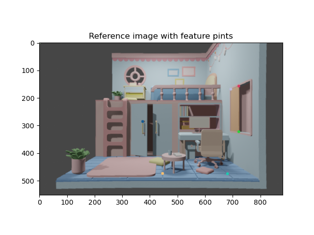

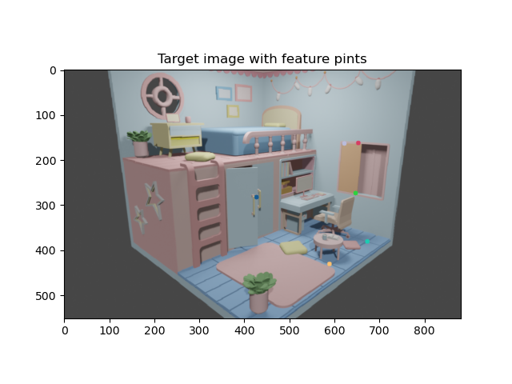

```python
# Display the result
plt.figure()
plt.title("Reference image with feature pints")
plt.imshow(cv.cvtColor(vis_img_ref, cv.COLOR_BGR2RGB))

plt.figure()
plt.title("Target image with feature pints")
plt.imshow(cv.cvtColor(vis_img_target, cv.COLOR_BGR2RGB))
```

```python
def transform_points(points, transformation):

    # Convert to homogeneous coordinates
    points_homogeneous = np.hstack([points, np.ones((len(points), 1))])
    # Apply transformation
    transformed_points = (np.linalg.inv(transformation) @ points_homogeneous.T).T
    # Convert back to 3D points
    return transformed_points[:, :3] / transformed_points[:, 3:]
```

```python
def create_point_cloud(rgb_image, depth_image, camera_intrinsics, pose):

    height, width = depth_image.shape

    # Create pixel coordinate grid
    xx, yy = np.meshgrid(np.arange(width), np.arange(height))
    xx = xx.reshape(-1)
    yy = yy.reshape(-1)

    # Get focal length and principal point from intrinsics
    fx = camera_intrinsics[0, 0]
    fy = camera_intrinsics[1, 1]
    cx = camera_intrinsics[0, 2]
    cy = camera_intrinsics[1, 2]

    # Convert depth to meters
    z = depth_image.reshape(-1)

    # Calculate 3D coordinates
    x = (xx - cx) * z / fx
    y = (yy - cy) * z / fy

    # Stack points and remove invalid depths
    points = np.stack([x, y, z], axis=-1)
    valid_mask = z > 0
    points = points[valid_mask]

    # Get colors
    colors = rgb_image.reshape(-1, 3)[valid_mask]

    # Apply camera pose transformation if provided
    points = transform_points(points, pose)

    return points.astype(np.float32), colors.astype(np.float32)
```

```python
def create_multiview_ply(rgb_images, depth_images, camera_intrinsics, camera_poses, output_path):

    all_points = []
    all_colors = []

    # Process each view
    for rgb, depth, pose in zip(rgb_images, depth_images, camera_poses):
        points, colors = create_point_cloud(rgb, depth, camera_intrinsics, pose)
        all_points.append(points)
        all_colors.append(colors)

    # Combine all points and colors
    points = np.vstack(all_points)
    colors = np.vstack(all_colors)

    print(points.shape)
    print(colors.shape)

#     ply_creator(points, colors, output_path)
    # Write PLY file
    with open(output_path, 'w') as f:
        # Write header
        f.write("ply\n")
        f.write("format ascii 1.0\n")
        f.write(f"element vertex {len(points)}\n")
        f.write("property float x\n")
        f.write("property float y\n")
        f.write("property float z\n")
        f.write("property uchar red\n")
        f.write("property uchar green\n")
        f.write("property uchar blue\n")
        f.write("end_header\n")

        # Write vertex data
        for (x, y, z), (r, g, b) in zip(points, colors):
            f.write(f"{x:.6f} {y:.6f} {z:.6f} {int(r)} {int(g)} {int(b)}\n")
```

```python
create_multiview_ply(image_list, true_depth_image_list, camera_matrix, pose_list, os.path.join(ply_path, "dense_recon.ply"))
```

```
(4368879, 3)
(4368879, 3)
```

```python
print(corr_idx)
print(corr_idx_rev)

matches = list(zip(list(range(7)), corr_idx))
print(matches)
matches_rev = list(zip(list(range(7)), corr_idx_rev))
print(matches_rev)

valid_matches = []
valid_matches_rev = []

for match in list(matches):
    if (match[1], match[0]) in matches_rev:
        valid_matches.append(match)
        valid_matches_rev.append((match[1], match[0]))

print(valid_matches)
print(valid_matches_rev)
```

```
[5 2 1 6 0 0 0]
[3 2 1 3 0 0 3]
[(0, 5), (1, 2), (2, 1), (3, 6), (4, 0), (5, 0), (6, 0)]
[(0, 3), (1, 2), (2, 1), (3, 3), (4, 0), (5, 0), (6, 3)]
[(0, 5), (1, 2), (2, 1), (3, 6)]
[(5, 0), (2, 1), (1, 2), (6, 3)]
```

```python
print(z_max_avg)
```

```
[5.999417640982829, 5.364391553441544, 5.748168390777626, 6.274606744285986, 5.424873461538865, 5.539154369318733, 6.0614893119621565, 4.369988288780693, 5.162826086614972]
```

```python
# triangualte feature points
image0 = image_list[0]
image1 = image_list[1]

cam_movement = camera_movement[0]

# feature points
points0 = given_features[0][:, ::-1].T.astype(float)
points1 = given_features[1][:, ::-1].T.astype(float)

# feature points homogeneous
points0_h = np.vstack([points0, np.ones((points0.shape[1]))])
points1_h = np.vstack([points1, np.ones((points1.shape[1]))])

# camera poses
pose0 = np.eye(4)
# pose1 = np.linalg.inv(cam_movement)
pose1 = cam_movement

# get fundamental matrix
F01 = compute_fundamental_matrix(camera_matrix, camera_matrix, pose0, pose1)

# compute epipolar lines
l01 = F01 @ points0_h

# vis epipolar lines
vis_colors = generate_colors(points0.shape[1])
vis_img_0_points = draw_points(image0, points0.T, vis_colors)
vis_img_1_lines = image1.copy()
for i in range(l01.shape[1]):
    vis_img_1_lines = draw_line(vis_img_1_lines, l01[:, i], color=vis_colors[i])

# find correspondences
distance_matrix = find_correspondences(points0, points1, l01)
corr_idx = np.argmin(distance_matrix, axis=1)

points1_sorted_h = np.empty(points1_h.shape)
for i in range(points1_h.shape[1]):
    points1_sorted_h[:, corr_idx[i]] = points1_h[:, i]
points1_sorted = points1_sorted_h[:2, :]

vis_img_1_corr = draw_points(image1, points1_sorted_h[:2, :].T, vis_colors)

# compute x2.T @ F @ x1
f_residuals = []
for i in range(points0.shape[1]):
    x2 = points1_sorted_h[:, [i]]
    x1 = points0_h[:, [i]]

    res = x2.T @ F01 @ x1
    f_residuals.append(res)

print(f_residuals)
print(l01)
print(F01)
print(distance_matrix)


# projection matrices
proj_mat0 = camera_matrix @ pose0[:3, :]
proj_mat1 = camera_matrix @ pose1[:3, :]



# triangulate feature points
points4d = cv.triangulatePoints(proj_mat0, proj_mat1, points0, points1_sorted)
points3d = points4d[:3, :] / points4d[3, :]
point3d_homo = points4d / points4d[3, :]
# print(points4d)
# print(points3d)
# print(point3d_homo)

# reproject the triangulated points
reproj_points0 = proj_mat0 @ point3d_homo
reproj_points1 = proj_mat1 @ point3d_homo

reproj_points0 = reproj_points0 / reproj_points0[2, :]
reproj_points1 = reproj_points1 / reproj_points1[2, :]

print("points: frame 00 ", points0.T)
print("reprojected points: frame 00 ", reproj_points0[:2, :].T)
print("points: frame 01 ", points1_sorted.T)
print("reprojected points: frame 01 ", reproj_points1[:2, :].T)


# features0 = given_features[0][:, ::-1].T.astype(float)
# features0_h = np.vstack([features0, np.ones(features0.shape[1])])

# points0 = np.linalg.inv(camera_matrix) @ features0_h
# points01 = pose_01[:3, :3] @ points0 + pose_01[:3, [3]]

# points01_h = points01 / points01[2, :]
# points01_img = camera_matrix @ points01_h

# print(features0_h)
# print(points01_img)

# print(features0_h[:, 0])
# print(points01[:, 0])
```

```
[array([[-0.00666608]]), array([[0.00296127]]), array([[0.00197158]]), array([[0.00606938]]), array([[-0.00036367]]), array([[0.00296333]]), array([[0.00074946]])]
[[-1.38099406e-04 -7.91805941e-04 -6.67406563e-04 -1.40538609e-04
  -6.62528156e-04 -4.23486214e-04 -4.08850993e-04]
 [ 3.89367372e-03  4.00204219e-03  3.72400325e-03  3.74200163e-03
   4.44819309e-03  4.57556031e-03  3.78841195e-03]
 [-6.23367386e-01 -1.62490416e+00 -1.40692836e+00 -6.10926054e-01
  -1.47658202e+00 -1.12811386e+00 -1.02220998e+00]]
[[ 1.05126491e-22 -2.43920349e-06  2.59490763e-04]
 [-3.44955466e-06  1.08316070e-07  6.00094387e-03]
 [ 3.66975356e-04 -3.70558337e-03 -2.45414116e-01]]
[[6.29092158e+00 3.50080644e+02 3.10251919e+02 1.62081922e+00
  2.44787667e+02 1.20859475e+02 1.54845621e+02]
 [1.71095318e+00 3.53475032e+02 3.14171382e+02 6.32198306e+00
  2.49564562e+02 1.27240691e+02 1.60789307e+02]
 [2.22015282e+02 9.40414113e+01 5.84414324e+01 2.17909197e+02
  8.08637386e-02 1.09884330e+02 7.97940741e+01]
 [3.11617141e+02 3.90622051e+01 5.21121569e-01 3.07072022e+02
  6.53659354e+01 1.87394384e+02 1.54023305e+02]
 [3.18883438e+02 7.25869035e-01 3.66845349e+01 3.14765797e+02
  9.55661489e+01 2.06287198e+02 1.76019483e+02]
 [1.60832167e+02 1.95515507e+02 1.55491726e+02 1.56187874e+02
  8.98162100e+01 3.41440141e+01 1.96686646e-01]
 [1.08498458e+02 1.94637570e+02 1.60626574e+02 1.04543003e+02
  1.04797575e+02 6.44886897e-01 2.82399486e+01]]
points: frame 00  [[616. 163.]
 [593. 431.]
 [672. 380.]
 [660. 164.]
 [462. 378.]
 [422. 280.]
 [650. 274.]]
reprojected points: frame 00  [[615.97001434 162.38227367]
 [593.08271827 431.29226297]
 [672.04556395 380.17796339]
 [660.03044528 164.55498797]
 [461.9921931  377.96317047]
 [422.04185258 280.31719265]
 [650.01045021 274.06805191]]
points: frame 01  [[694. 183.]
 [446. 495.]
 [651. 495.]
 [722. 192.]
 [444. 398.]
 [376. 282.]
 [704. 346.]]
reprojected points: frame 01  [[693.97022662 183.85563812]
 [446.06980713 494.64771381]
 [651.04565383 494.74556028]
 [722.03095947 191.18930242]
 [443.99407099 398.03981611]
 [376.02979308 281.67899758]
 [704.01054862 345.90232665]]
```

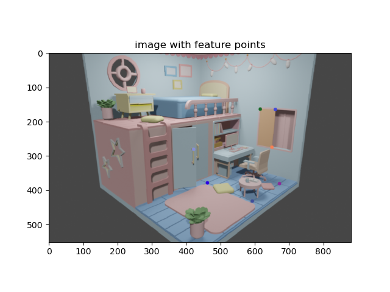

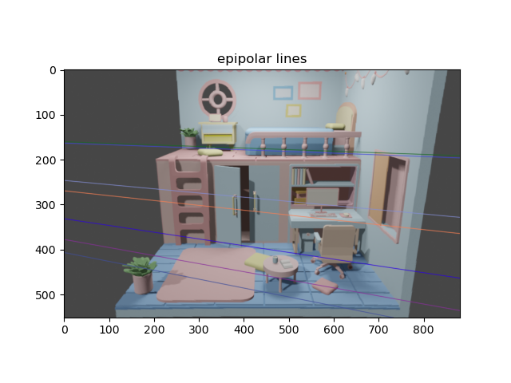

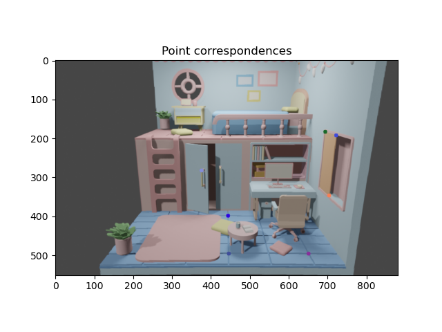

```python
# Display the result
plt.figure()
plt.title("image with feature points")
plt.imshow(cv.cvtColor(vis_img_0_points, cv.COLOR_BGR2RGB))

plt.figure()
plt.title("epipolar lines")
plt.imshow(cv.cvtColor(vis_img_1_lines, cv.COLOR_BGR2RGB))

plt.figure()
plt.title("Point correspondences")
plt.imshow(cv.cvtColor(vis_img_1_corr, cv.COLOR_BGR2RGB))
```